# Current Contraceptive Use Among Women Aged 15–49 in Ethiopia

A weighted descriptive analysis of the 2019 Ethiopia Demographic and Health Survey Data

Awet Ghebreberhan Mehretab

2026-08-02

## Introduction

Family planning is one of the most cost-effective investments in public health. When women are able to choose whether and when to become pregnant, maternal and newborn deaths fall, pregnancies are spaced more safely, and households and health systems are placed under less strain. Ethiopia has made family planning a central pillar of its health policy for more than two decades, expanding community-based services through its network of Health Extension Workers. Yet national averages can hide large gaps between richer and poorer women, between regions, and across the life course.

This report uses the **2019 Ethiopia Demographic and Health Survey (EMDHS)** to describe how *current* contraceptive use varies among women of reproductive age. Rather than treating Ethiopian women as a single group, it asks a simple equity question: **who is using contraception, and who is being left behind?**

## Aims

The analysis has four objectives:

1. Estimate the overall prevalence of current contraceptive use among women aged 15–49.
2. Describe the mix of methods that women rely on.
3. Compare contraceptive use across age, education, household wealth, place of residence, and administrative region.
4. Identify which of these dimensions produces the widest inequality, and therefore where policy attention would go furthest.

## Methods

Data come from the women’s individual recode (IR) file of the 2019 Ethiopia DHS data. Nine variables were retained: age group, highest education level, household wealth quintile, urban/rural residence, region, current contraceptive method, and the three survey-design variables (sample weight, primary sampling unit, and stratum).

Labelled Stata variables were converted to ordinary R factors and category labels were tidied for presentation. A binary indicator of *any current use* was derived from the reported method; women with a missing method were excluded rather than assumed to be users. A total of 8,885 women were surveyed.

All estimates are **weighted** using the DHS sample weight (v005/1,000,000), and confidence intervals account for the stratified two-stage cluster design through the survey’s primary sampling units and strata. Every percentage in this report is calculated directly from the weighted survey object, with denominators derived from the data rather than entered by hand.

## Findings

### Population

Table 1 summarises the socio-demographic profile of the women analysed.

**Table 1. Characteristics of Ethiopian women aged 15–49**

2019 Ethiopia DHS, weighted percentages

| Category | Unweighted N | Weighted % |
| --- | --- | --- |
| Age group |  |  |
| 15-19 | 2,100 | 24.9% |
| 20-24 | 1,578 | 16.7% |
| 25-29 | 1,752 | 18.8% |
| 30-34 | 1,166 | 13.1% |
| 35-39 | 1,037 | 12.0% |
| 40-44 | 714 | 8.3% |
| 45-49 | 538 | 6.3% |
| Education |  |  |
| No education | 3,640 | 40.4% |
| Primary | 3,345 | 41.7% |
| Secondary | 1,149 | 12.2% |
| Higher | 751 | 5.7% |
| Wealth quintile |  |  |
| Poorest | 2,031 | 16.2% |
| Poorer | 1,341 | 18.2% |
| Middle | 1,268 | 18.8% |
| Richer | 1,344 | 21.1% |
| Richest | 2,901 | 25.7% |
| Residence |  |  |
| Urban | 2,951 | 32.2% |
| Rural | 5,934 | 67.8% |

*Percentages are weighted to the national population; N is the unweighted number of women surveyed.*

### Overall use and the method mix

Overall, **28.8% of women aged 15–49 were currently using a contraceptive method** (95% CI 26.1%–31.4%; Figure 1), meaning that 71.2% of women were not. Among those who did use a method, injectables and implants together account for 85.8% of all use, while pills, IUDs, and condoms together make up only a small share (Figure 2). This heavy reliance on two provider administered methods has an important policy implication: contraceptive access in Ethiopia is closely tied to the reach of health services rather than to products women can obtain and manage themselves.

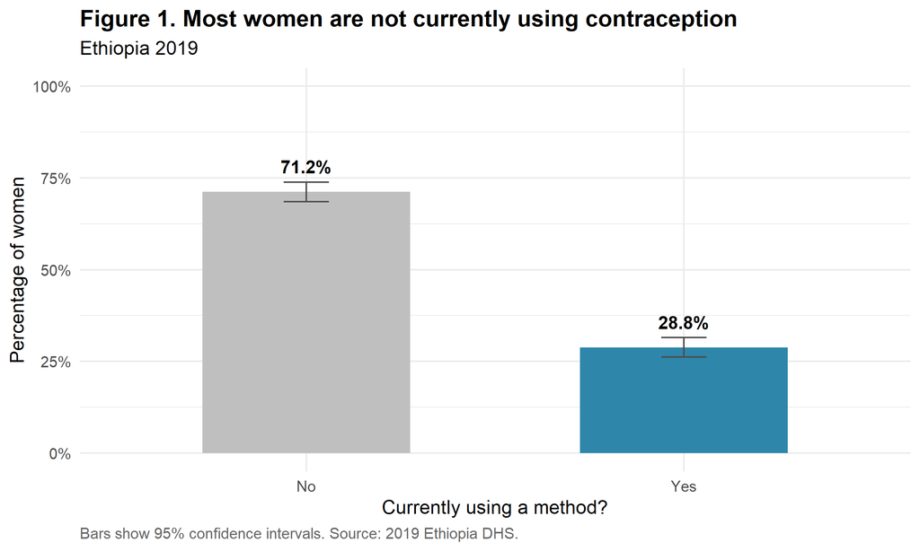

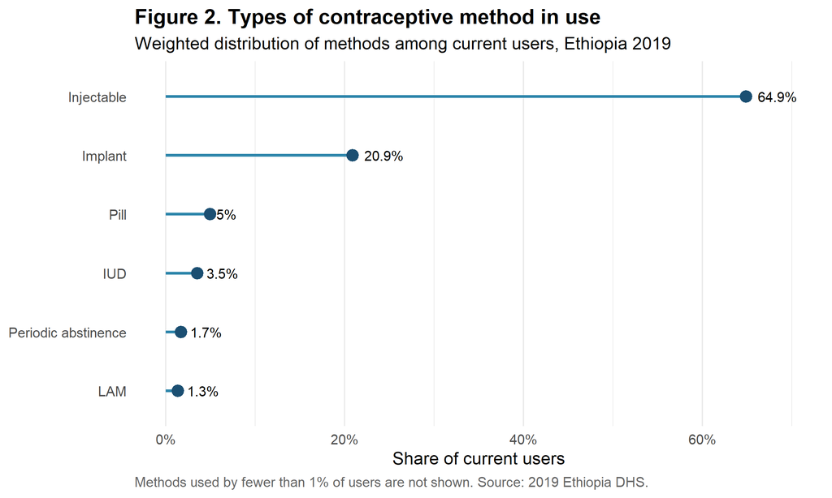

### Contraceptive use with age

Contraceptive use follows a clear inverted-U pattern across the life course (Figure 3). It is lowest among adolescents aged 15–19, at 9.4%, climbs steeply to a peak of 41.4% among women aged 25-29, the prime childbearing years, when women are most likely to be spacing or limiting births — and then declines again as women approach the end of their reproductive lives. Reaching the youngest and oldest women therefore calls for different service strategies.

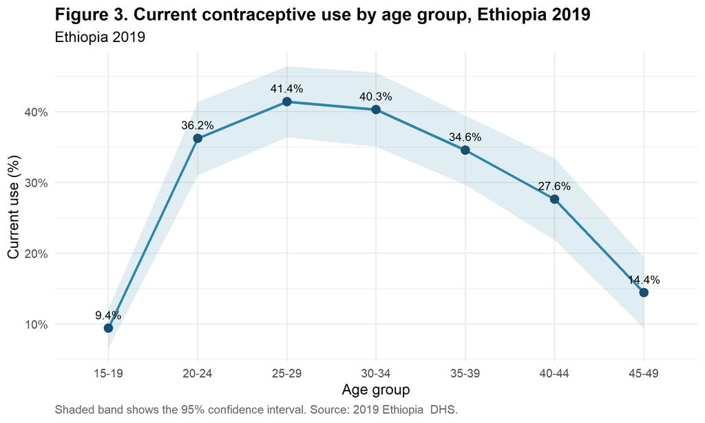

### Wealth divides women more than education does

Household wealth is one of the sharpest dividing lines in the data (Figure 4). Women in the poorest quintile are far less likely to use contraception than women in every wealthier group; use is 1.6 times higher in the middle quintile than in the poorest before levelling off. Education, by contrast, shows no consistent pattern (Figure 5). Use ranges only from 27.3% among women with secondary schooling to 33.0% among those with higher education, a spread of under six percentage points, and the confidence intervals overlap across every group. Taken together, these two figures suggest that economic access the ability to reach and afford services, divides Ethiopian women more sharply than schooling does.

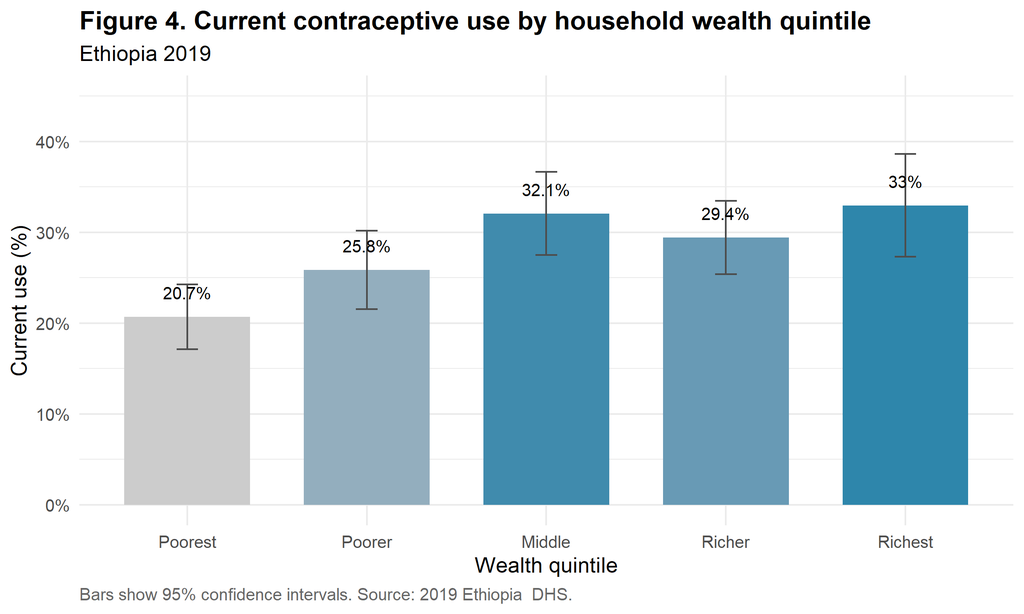

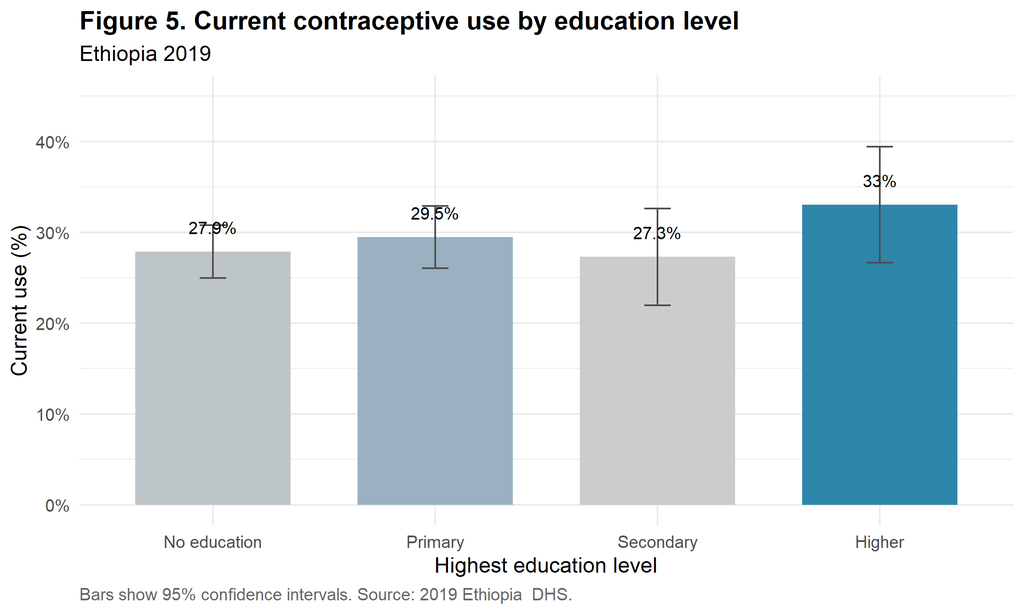

Wealth shapes not only *whether* a woman uses contraception but *what* she uses (Figure 6). Among current users in the poorest quintile, injectables account for 71% of all method use, and short-acting or self-managed options are almost absent: the pill makes up roughly 2% and the IUD less than 2%. Among the richest quintile, injectables fall to 58% while the pill rises to 12% and the IUD to around 5%. Poorer women therefore depend on a narrow, service-dependent set of options concentrated in the injectables and implants delivered through the Health Extension Programme, whereas wealthier women draw on a broader mix that includes methods obtained through pharmacies and private providers.

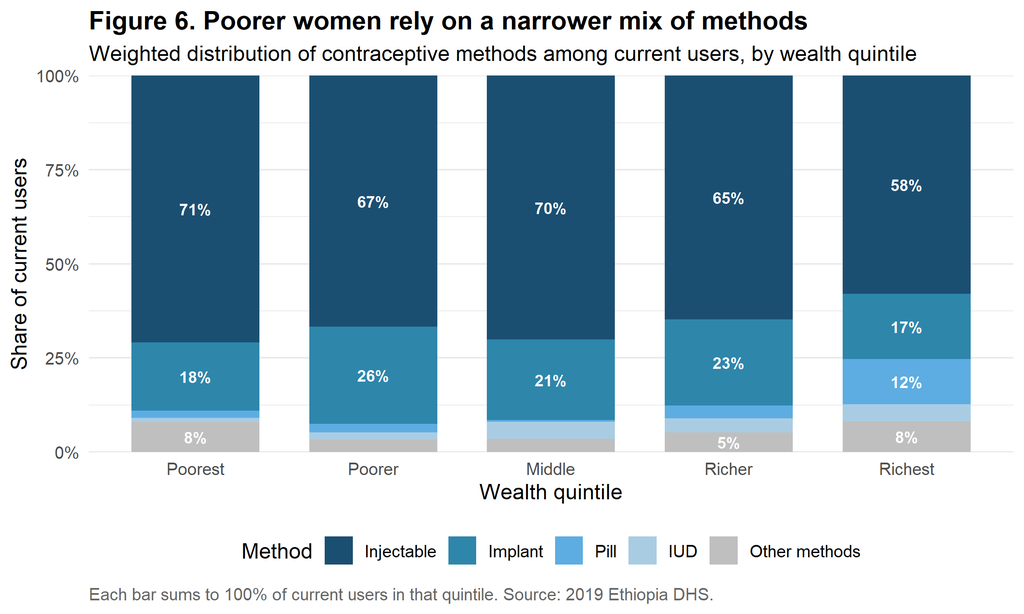

### Regional use of contraceptives

The starkest inequalities are geographic (Figure 7). Current use ranges from 2.8% in Somali to 34.4% in Amhara. This 12-fold gap between the lowest- and highest-using regions dwarfs the differences seen across wealth or education, and points to the combined influence of geography, culture, and the uneven reach of health services in sparsely populated pastoralist areas.

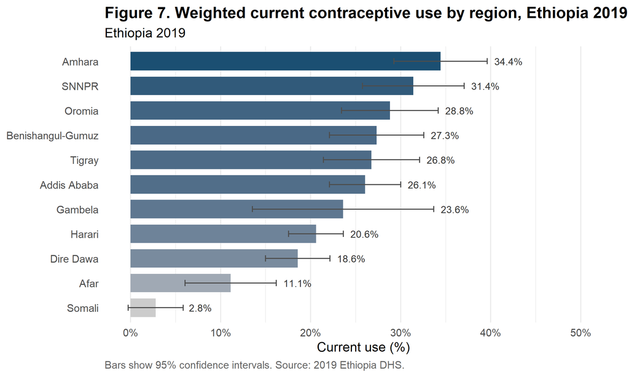

## Conclusion

28.8% of Ethiopian women of reproductive age were using contraception in 2019, and that use rested heavily on just two provider-administered methods, which together accounted for 85.8% of all method use. But the national figure conceals deep inequalities. The women least likely to be protected are the poorest, the very youngest and oldest, and above all those living in the pastoralist regions, where use falls to 2.8% against 34.4% in the highest-using region. Poorer women are also confined to a narrower method mix, so inequality operates on both access and choice. Because the widest gaps are geographic and economic rather than educational, efforts to raise contraceptive use are likely to gain the most from targeting underserved regions and the poorest households, and from broadening the method mix so that women have more self-managed options. Narrowing these gaps would move Ethiopia closer to genuinely universal access to family planning.

## Limitations

This is a descriptive, cross-sectional analysis. Estimates are weighted and confidence intervals account for the complex survey design, but no multivariable adjustment was performed, so the associations shown may reflect confounding between correlated characteristics, wealth, region, and education move together in Ethiopia. Contraceptive use is self-reported and may be under-reported where it is stigmatised. Some regions contribute small samples, so their estimates carry wide confidence intervals, which the figures make explicit. Finally, the 2019 survey is a *mini* DHS with a reduced questionnaire, so measures of unmet need, method source, and discontinuation are not available. The findings describe associations and inequalities, not causes.